# DWLGRE003 Reproducible Research Deliverable

Grethen de Waal

2026-02-25

### Introduction

The dataset I have selected shows the number of TB cases per 100,000 for each age group, divided by sex, for 201 countries in the year 2000.

This data were taken from a [Udemy R course](https://www.udemy.com/course/r-programming-for-statistics-and-data-science/) I did, and was originally sourced from WHO, likely [this report](https://iris.who.int/server/api/core/bitstreams/e031e926-f850-4d6d-a99f-d6ae841add4b/content).

### Tidying the data

To tidy the data, I used the tidyverse, ggplot2 and countrycode packages.

#### Loading the packages

```r
library(tidyverse)
```

```r
library(ggplot2)
library(countrycode)
```

#### Loading the data

```r
tb <- read_csv("data/tb_untidy.csv")
tb <- as_tibble(tb)

tb
```

```
## # A tibble: 201 × 22
##    country  year m04   m514   m014 m1524 m2534 m3544 m4554 m5564   m65 mu
##    <chr>   <dbl> <lgl> <lgl> <dbl> <dbl> <dbl> <dbl> <dbl> <dbl> <dbl> <lgl>
##  1 AD       2000 NA    NA        0     0     1     0     0     0     0 NA
##  2 AE       2000 NA    NA        2     4     4     6     5    12    10 NA
##  3 AF       2000 NA    NA       52   228   183   149   129    94    80 NA
##  4 AG       2000 NA    NA        0     0     0     0     0     0     1 NA
##  5 AL       2000 NA    NA        2    19    21    14    24    19    16 NA
##  6 AM       2000 NA    NA        2   152   130   131    63    26    21 NA
##  7 AN       2000 NA    NA        0     0     1     2     0     0     0 NA
##  8 AO       2000 NA    NA      186   999  1003   912   482   312   194 NA
##  9 AR       2000 NA    NA       97   278   594   402   419   368   330 NA
## 10 AS       2000 NA    NA       NA    NA    NA    NA     1     1    NA NA
## # ℹ 191 more rows
## # ℹ 10 more variables: f04 <lgl>, f514 <lgl>, f014 <dbl>, f1524 <dbl>,
## #   f2534 <dbl>, f3544 <dbl>, f4554 <dbl>, f5564 <dbl>, f65 <dbl>, fu <lgl>
```

#### Identifying the problems

There are **five key problems** with the data:

1. There are many NA entries - can remove these with pivot_longer().
2. Column with sex and age needs split and be made into observations.
3. The age groups need to be split with a hyphen using mutate().
4. Country codes should have names.
5. The “year” column is unnecessary because it is the same for each entry.

#### Running the code

**Problems 1 and 2** were dealt with simultaneously:

Remove the NA observations, shift the age and sex columns (e.g. m014, m1524, etc.) into observations and split them across two separate columns.

```r
tb_tidy <- tb %>%
  pivot_longer(                  # reshapes data from wide to long format
    cols = m04:fu,               # tells R which columns to move
    names_to = c("sex", "age"),  # tells R what to name the new columns
    names_pattern = "(.)(.*)",   # tells R how to split the first letter from everything that follows
    values_to = "cases",         # tells R where to put the observations from the columns we shifted
    values_drop_na = TRUE        # gets rid of "NA" observations
    )
```

**Problem 3**

The age ranges need to be split.

With this code below, entries like “014” are split with a hyphen, and will end up looking like “0-14”. Since 65 does not come with an age range, I just said “65+”.

```r
tb_tidy <- tb_tidy %>%
  mutate(age = case_when(
    age == "014" ~ "0-14",
    age == "1524" ~ "15-24",
    age == "2534" ~ "25-34",
    age == "3544" ~ "35-44",
    age == "4554" ~ "45-54",
    age == "5564" ~ "55-64",
    age == "65"   ~ "65+",
    TRUE ~ age                  # this keeps everything else as is
  ))
```

**Problem 4**

The country codes need to have names.

```r
# Extract country names from country codes
# use iso2c: ISO-2 character

# Insert country names in new column
tb_tidy <- tb_tidy %>%
  mutate(country_name = countrycode(country, origin = "iso2c", destination = "country.name"))
```

```
## Warning: There was 1 warning in `mutate()`.
## ℹ In argument: `country_name = countrycode(country, origin = "iso2c",
##   destination = "country.name")`.
## Caused by warning:
## ! Some values were not matched unambiguously: AN
```

```r
# Reorder columns
tb_tidy <- tb_tidy %>%
  relocate(country, country_name)

tb_tidy
```

```
## # A tibble: 2,273 × 6
##    country country_name          year sex   age   cases
##    <chr>   <chr>                <dbl> <chr> <chr> <dbl>
##  1 AD      Andorra               2000 m     0-14      0
##  2 AD      Andorra               2000 m     15-24     0
##  3 AD      Andorra               2000 m     25-34     1
##  4 AD      Andorra               2000 m     35-44     0
##  5 AD      Andorra               2000 m     45-54     0
##  6 AD      Andorra               2000 m     55-64     0
##  7 AD      Andorra               2000 m     65+       0
##  8 AE      United Arab Emirates  2000 m     0-14      2
##  9 AE      United Arab Emirates  2000 m     15-24     4
## 10 AE      United Arab Emirates  2000 m     25-34     4
## # ℹ 2,263 more rows
```

Country code AN does not exist in the countrycode package (Warning message: “Some values were not matched unambiguously: AN”).

I tried using the mutate() function the way I used it to add the hyphens in the age ranges but it didn’t work, so I kept both the country codes and the names. For the sake of brevity, I did not include the code in this file, but it is available in tb_tidying.R.

**Problem 5** Removing the year column.

```r
tb_tidied <- tb_tidy %>%
  select(-year)
```

### Export tidied dataset

```r
write.csv(tb_tidied, file = "data/tb_tidied.csv", row.names = FALSE)
```

### Creating charts

Because the number of cases is a continuous variable and the sex is discrete, I converted the data into a box plot and a bar chart.

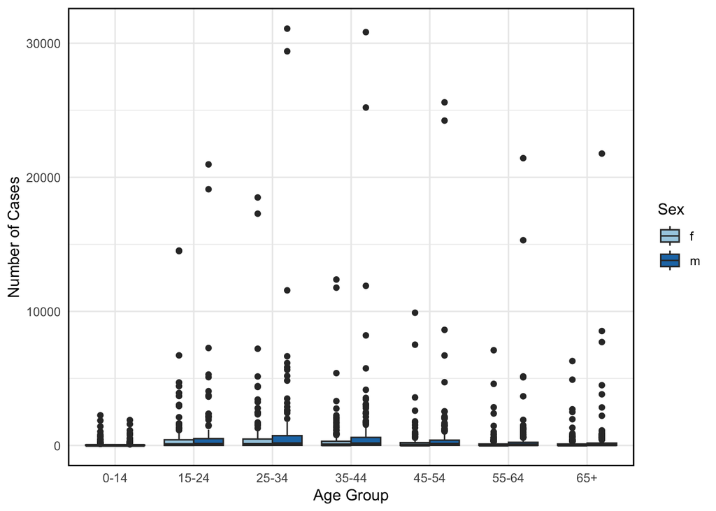

```r
# box plot
tidy_box <- ggplot(tb_tidy, aes(x = age, y = cases, fill = sex)) +
  geom_boxplot(position = "dodge") +
  theme_minimal() +
  scale_fill_brewer(palette = "Paired") +
  theme(panel.border = element_rect(colour = "black", fill = NA, linewidth = 1)) +
  labs(x = "Age Group",
        y = "Number of Cases",
        fill = "Sex")

tidy_box
```

**Figure 1:** A box plot of TB cases by age and sex, per country, in the year 2000.

The box plot shows the overall spread of data well, but it’s very difficult to see the interquartile range.

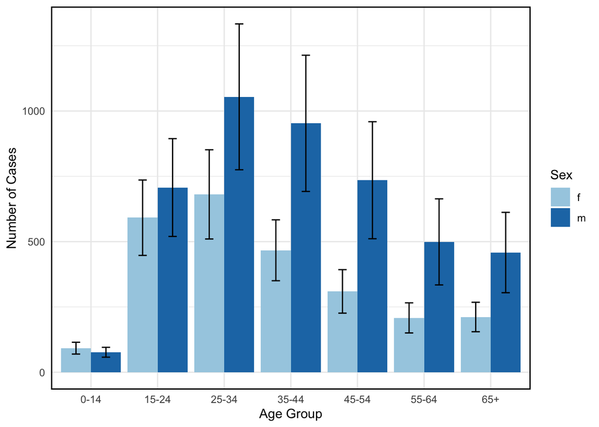

```r
# bar chart
 tb_summary <- tb_tidy %>%
   group_by(age, sex) %>%
   summarise(
     mean_cases = mean(cases, na.rm = TRUE),
     se_cases = sd(cases, na.rm = TRUE) / sqrt(n()),
     .groups = "drop")


tidy_bar <- ggplot(tb_summary, aes(x = age, y = mean_cases, fill = sex)) +
  geom_col(position = "dodge") +
  geom_errorbar(
    aes(ymin = mean_cases - se_cases, ymax = mean_cases + se_cases),
    position = position_dodge(width = 0.9),
    width = 0.25) +
  scale_fill_brewer(palette = "Paired") +
   theme_minimal() +
  theme(
    panel.border = element_rect(colour = "black", fill = NA, linewidth = 1)) +
  labs(x = "Age Group",
       y = "Number of Cases",
       fill = "Sex")

tidy_bar
```

**Figure 2:** A bar chart of TB cases by age and sex, per country, in the year 2000.